# Col de la Porte

#### Model: GEOtop v3.0

Compiler: gcc version 4.8.4 (Ubuntu 4.8.4-2ubuntu1~14.04.1) Processor: Intel(R) Core(TM) i7-5500U CPU @ 2.40GHz Author: Stefano Endrizzi (stefano.end@gmail.com),Emanuele Cordano (emanuele.cordano@rendena100.eu) Date: 25-11-2016

#### Name: ColdelaPorte

Description: Simulation 1D over the Col de la Porte dataset to test the capability of GEOotp to simulate snow depth, snow water equivalent, soil temperature.

#### Results published in:

- Snow Height (Snow Dapth);
- Snow Water Equivalent;
- Soil Temperature at 10 cm depth;
- Soil temparature at 20 cm depth;
- Soil Temparature at 50 cm depth;
- Surface Temparature ;
- Albedo .

#### Simulation duration:

InitDateDDMMYYYYhhmm = 21/09/2001 00:00 EndDateDDMMYYYYhhmm = 10/04/2002 00:00

### Output:

PointOutputFile = “output-tabs/surface”

### Observations:

Snow heigth mm, Snow Water Equivalent mm(NOT FOUND), T surface C, T soil 10cm C,T soil 20cm C,T soil 50cm C see Morin et al. (2012).

### Winter 2001/2002

Here is a comparison plot:

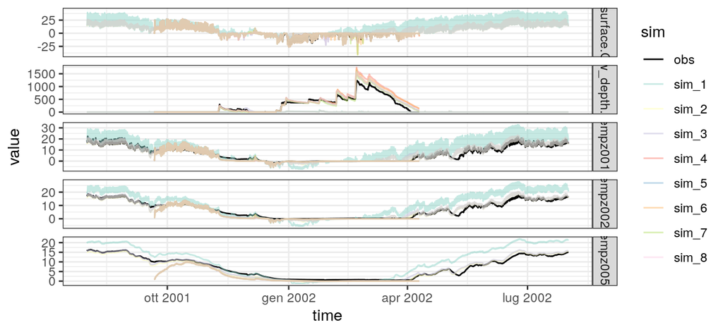

Goodness of fit:

| sim | gof | Tsurface.C. | snow_depth.mm. | tempz0010 | tempz0020 | tempz0050 |
| --- | --- | --- | --- | --- | --- | --- |
| obs | MAE | 0.00 | 0.00 | 0.00 | 0.00 | 0.00 |
| obs | RMSE | 0.00 | 0.00 | 0.00 | 0.00 | 0.00 |
| obs | KGE | 1.00 | 1.00 | 1.00 | 1.00 | 1.00 |
| sim_1 | MAE | 3.54 | 274.16 | 4.65 | 4.33 | 3.44 |
| sim_1 | RMSE | 4.68 | 417.66 | 5.94 | 5.37 | 4.31 |
| sim_1 | KGE | 0.39 | -0.59 | 0.25 | 0.28 | 0.37 |
| sim_2 | MAE | 4.24 | 274.53 | 1.10 | 1.05 | 0.82 |
| sim_2 | RMSE | 5.63 | 418.00 | 1.58 | 1.40 | 0.97 |
| sim_2 | KGE | 0.07 | -0.58 | 0.92 | 0.90 | 0.92 |
| sim_3 | MAE | 4.29 | 275.33 | 1.16 | 1.10 | 0.73 |
| sim_3 | RMSE | 5.68 | 418.09 | 1.65 | 1.47 | 0.93 |
| sim_3 | KGE | 0.06 | -0.70 | 0.91 | 0.89 | 0.92 |
| sim_4 | MAE | 1.96 | 93.14 | 0.85 | 1.00 | 1.49 |
| sim_4 | RMSE | 2.93 | 154.37 | 1.42 | 1.44 | 1.98 |
| sim_4 | KGE | 0.74 | 0.57 | 0.80 | 0.73 | 0.57 |
| sim_5 | MAE | 2.08 | 62.10 | 0.86 | 1.01 | 1.52 |
| sim_5 | RMSE | 3.29 | 97.14 | 1.42 | 1.46 | 2.01 |
| sim_5 | KGE | 0.70 | 0.76 | 0.79 | 0.72 | 0.56 |
| sim_6 | MAE | 2.18 | 80.63 | 0.85 | 1.01 | 1.52 |
| sim_6 | RMSE | 3.48 | 130.52 | 1.42 | 1.46 | 2.01 |
| sim_6 | KGE | 0.64 | 0.66 | 0.80 | 0.72 | 0.56 |
| sim_7 | MAE | 2.12 | 55.42 | 0.85 | 0.99 | 1.50 |
| sim_7 | RMSE | 3.49 | 83.64 | 1.41 | 1.45 | 2.00 |
| sim_7 | KGE | 0.65 | 0.84 | 0.80 | 0.72 | 0.56 |
| sim_8 | MAE | 2.08 | 62.10 | 0.86 | 1.01 | 1.52 |
| sim_8 | RMSE | 3.29 | 97.14 | 1.42 | 1.46 | 2.01 |
| sim_8 | KGE | 0.70 | 0.76 | 0.79 | 0.72 | 0.56 |

### Winter 2002/2003

Here is a comparison plot:

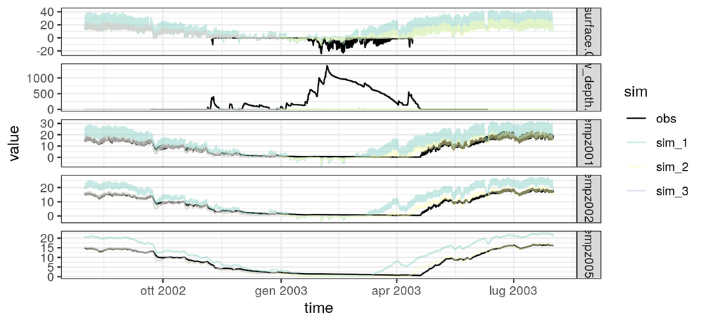

Goodness of fit:

[output not shown]

### References

Endrizzi, S., S. Gruber, M. Dall’Amico, and R. Rigon. 2014. “GEOtop 2.0: Simulating the Combined Energy and Water Balance at and Below the Land Surface Accounting for Soil Freezing, Snow Cover and Terrain Effects.” *Geoscientific Model Development* 7 (6): 2831–57. https://doi.org/10.5194/gmd-7-2831-2014.

Morin, S., Y. Lejeune, B. Lesaffre, J.-M. Panel, D. Poncet, P. David, and M. Sudul. 2012. “An 18-Yr Long (1993â€“2011) Snow and Meteorological Dataset from a Mid-Altitude Mountain Site (Col de Porte, France, 1325 M Alt.) for Driving and Evaluating Snowpack Models.” *Earth System Science Data* 4 (1): 13–21. https://doi.org/10.5194/essd-4-13-2012.